```python
import pandas as pd
import matplotlib.pyplot as plt
import scipy.fft as ffour
import numpy as np
```

```python
df_1P36A01R01=pd.read_csv('1P36A01R01.dat',delimiter=",", header=None, names=['vector_data'])
```

# File Format

The data have been organised in separate folders with .dat files for each data collection, with details provided in the remainder of this document. The data files have been named with this generic approach KPXXAYYRZ so that  the digits K 1 2 3 4 5 and 6 at the beginning indicates the activities walking, sitting down, stand up, pick up an object, drink water, and fall respectively;  the characters XX indicate the subject (individual person) having ID XX (01, 02, etc…); 2  the characters YY indicate the activity being performed such as A01, A02, A03, A04, A05, and A06;  the character Z indicates the repetition of the activity such as R1, R2, etc. Some information about the subjects (age, height, gender, dominant hand) is also reported in this document as metadata. Note also that in some cases not all the information were available, and this has been replaced by n/a for some subjects.

```python
df_1P36A01R01.shape
```

```
(1280004, 1)
```

```python
df_1P36A01R01.head(10)
```

|  | vector_data |
| --- | --- |
| 0 | 5800000000.000000 |
| 1 | 1.000000 |
| 2 | 128 |
| 3 | 400000000.000000 |
| 4 | 1812+1897i |
| 5 | 1782+2029i |
| 6 | 2265+2014i |
| 7 | 2286+1763i |
| 8 | 2401+2152i |
| 9 | 2342+2324i |

```python
df_1P36A01R01.describe()
```

|  | vector_data |
| --- | --- |
| count | 1280004 |
| unique | 804720 |
| top | 2033+2080i |
| freq | 12 |

# Array format

When imported into MATLAB (or equivalent software), each file is seen as a long 1D complex array (or table). The first 4 elements include in this order the carrier frequency (5.8 GHz), the duration of the chirp (1 ms), the number of samples per recorded beat-note signal (128 samples), and the bandwidth of the chirp (400 MHz); the following elements are the complex samples of the sequence of recorded beat-notes one after the other.

```python
df_1P36A01R01[4:]
```

|  | vector_data |
| --- | --- |
| 4 | 1812+1897i |
| 5 | 1782+2029i |
| 6 | 2265+2014i |
| 7 | 2286+1763i |
| 8 | 2401+2152i |
| ... | ... |
| 1279999 | 1996+1949i |
| 1280000 | 2129+2035i |
| 1280001 | 2111+2147i |
| 1280002 | 2058+2187i |
| 1280003 | 2004+2183i |

1280000 rows × 1 columns

```python
# drop the first 3 as they are duration, number of samples and bandwidth (the carrier frequency came through as
# the column name which we will rename later)

sample_info = df_1P36A01R01[:4].copy()
vector_df=df_1P36A01R01[4:].copy()
vector_df=vector_df.reset_index(drop=True)
print(vector_df.dtypes)
```

```
vector_data    object
dtype: object
```

```python
cumb_sample_df = np.array(vector_df).reshape(128, 10000)
cumb_sample_df.shape
```

```
(128, 10000)
```

```python
cumb_sample_df[0]
```

```
array(['1812+1897i', '1782+2029i', '2265+2014i', ..., '1754+1770i',
       '1914+1595i', '2122+1619i'], dtype=object)
```

```python
cumb_sample_df[0].shape
```

```
(10000,)
```

```python
from scipy.fft import fft, ifft, fftfreq, fft2, fftn, ifft2, ifftn

test = fft(cumb_sample_df[0])
test
```

[output not shown]

```python
test = ifft(cumb_sample_df[0])
test
```

[output not shown]

```python
test = fftfreq(cumb_sample_df[0])
test
```

[output not shown]

```python
test = fft2(cumb_sample_df[0])
test
```

[output not shown]

```python
test = ifft2(cumb_sample_df[0])
test
```

[output not shown]

```python
test = fftn(cumb_sample_df[0])
test
```

[output not shown]

```python
test = ifftn(cumb_sample_df[0])
test
```

[output not shown]

```python
from scipy.fft import rfft2, irfft2, rfftn, irfftn

test = rfft2(cumb_sample_df[0])
test
```

[output not shown]

```python
test = irfft2(cumb_sample_df[0])
test
```

[output not shown]

# Tips from Francesco

```python
real_list=[]
imaginary_list=[]
complex_list=[]
for c_num in cumb_sample_df: #['complex_array']
    c_split=c_num.split('+')
    real_list.append(int(c_split[0]))
    im_input=c_split[1]
    com_input=im_input.replace("i","")
    com_input=int(com_input)
    imaginary_list.append(com_input)
    complex_list.append(complex(int(c_split[0]),com_input))
```

[output not shown]

```python
cumb_sample_df=cumb_sample_df.assign(real_comp=real_list)
cumb_sample_df=cumb_sample_df.assign(im_comp=imaginary_list)
cumb_sample_df=cumb_sample_df.assign(complex_col=complex_list)
np_comp_array=cumb_sample_df['complex_col'].to_numpy(dtype=complex)
np_comp_reshape=np.reshape(np_comp_array,(10000,128))
comp_list_rb=[]
for comp_list in np_comp_reshape:
    list_rb=[]
    list_rb=ffour.fft(comp_list)
    comp_list_rb.append(list_rb)
comp_list_rb_abs=[]
max_abs=0
min_abs=0
for comp_list_abs in comp_list_rb:
    list_rb_abs=[]
    list_rb_abs=abs(comp_list_abs)
    max_list=max(list_rb_abs)
    min_list=min(list_rb_abs)
    if max_list>max_abs:
        max_abs=max_list
    if min_list< min_abs and not min_abs==0:
        min_abs=min_list
    elif min_abs==0:
        min_abs=min_list
    comp_list_rb_abs.append(list_rb_abs)
```

```python
print(cumb_sample_df.head(100))
```

[output not shown]

```python
print(real_list[0:4])
print(imaginary_list[0:4])
print(complex_list[0:4])
print(len(real_list))
#print(cumb_sample_df.dtypes)
#print(np_comp_array)
#print(np_comp_array.dtype)
#print(np_comp_reshape)
#print(np_comp_reshape.shape)
##print(list_rb)
#print(list_rb_abs)
print(min_abs)
print(max_abs)
```

[output not shown]

```
   Absolute_values
0    370411.175567
1      2335.739867
2      1503.475480
3      1435.227699
4      1457.870976
5      1882.958307
6      2102.611910
7      2547.913905
8      1657.275289
9      5427.939413
128
```

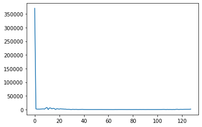

```python
df_abs_val=pd.DataFrame(list_rb_abs,columns=['Absolute_values'])
print(df_abs_val.head(10))
print(len(list_rb_abs))
plt.plot(df_abs_val['Absolute_values'])
plt.show()
```